# Project: Investigate a Dataset (TMDb Movie Data)

- Introduction
- Data Wrangling
- Exploratory Data Analysis
- Conclusions

## Introduction

For this project I chose to do the TMDb movie data dataset This data set contains information about 10,000 movies collected from The Movie Database (TMDb), including user ratings and revenue.

These are the questions I came up with and I plan to answer:

- Which year were movies released the most?
- Which genre is the most released?
- Which movie gained the highest vote?

```python
# These are the packages that will be used for this project.
import pandas as pd
import numpy as np
import matplotlib.pyplot as mplt
import seaborn as sns
%matplotlib inline
```

## Data Wrangling

### General Properties

```python
# In this step we are creating the dataset that we will be investigating.
tmdb_movies = pd.read_csv ('C:/Users/Lauren.Mukanda/Downloads/tmdb-movies.csv')

# This will print out the first 2 rows from the dataset.
tmdb_movies.head(2)

# This will print out the last 2 rows from the dataset.
tmdb_movies.tail(2)

# By looking at the print out we get to see all the columns and vairables available in the dataset.
```

|  | id | imdb_id | popularity | budget | revenue | original_title | cast | homepage | director | tagline | ... | overview | runtime | genres | production_companies | release_date | vote_count | vote_average | release_year | budget_adj | revenue_adj |
| --- | --- | --- | --- | --- | --- | --- | --- | --- | --- | --- | --- | --- | --- | --- | --- | --- | --- | --- | --- | --- | --- |
| 10864 | 21449 | tt0061177 | 0.064317 | 0 | 0 | What's Up, Tiger Lily? | Tatsuya Mihashi\|Akiko Wakabayashi\|Mie Hama\|Joh... | NaN | Woody Allen | WOODY ALLEN STRIKES BACK! | ... | In comic Woody Allen's film debut, he took the... | 80 | Action\|Comedy | Benedict Pictures Corp. | 11/2/66 | 22 | 5.4 | 1966 | 0.000000 | 0.0 |
| 10865 | 22293 | tt0060666 | 0.035919 | 19000 | 0 | Manos: The Hands of Fate | Harold P. Warren\|Tom Neyman\|John Reynolds\|Dian... | NaN | Harold P. Warren | It's Shocking! It's Beyond Your Imagination! | ... | A family gets lost on the road and stumbles up... | 74 | Horror | Norm-Iris | 11/15/66 | 15 | 1.5 | 1966 | 127642.279154 | 0.0 |

2 rows × 21 columns

```python
# We want to get the info of the data to see if there are any mistakes that needs to be addressed.
tmdb_movies.info()
```

```
<class 'pandas.core.frame.DataFrame'>
RangeIndex: 10866 entries, 0 to 10865
Data columns (total 21 columns):
 #   Column                Non-Null Count  Dtype
---  ------                --------------  -----
 0   id                    10866 non-null  int64
 1   imdb_id               10856 non-null  object
 2   popularity            10866 non-null  float64
 3   budget                10866 non-null  int64
 4   revenue               10866 non-null  int64
 5   original_title        10866 non-null  object
 6   cast                  10790 non-null  object
 7   homepage              2936 non-null   object
 8   director              10822 non-null  object
 9   tagline               8042 non-null   object
 10  keywords              9373 non-null   object
 11  overview              10862 non-null  object
 12  runtime               10866 non-null  int64
 13  genres                10843 non-null  object
 14  production_companies  9836 non-null   object
 15  release_date          10866 non-null  object
 16  vote_count            10866 non-null  int64
 17  vote_average          10866 non-null  float64
 18  release_year          10866 non-null  int64
 19  budget_adj            10866 non-null  float64
 20  revenue_adj           10866 non-null  float64
dtypes: float64(4), int64(6), object(11)
memory usage: 1.7+ MB
```

```python
# We want to see a discriptive statistics summary for each columns which can be very useful.
tmdb_movies.describe()
```

|  | id | popularity | budget | revenue | runtime | vote_count | vote_average | release_year | budget_adj | revenue_adj |
| --- | --- | --- | --- | --- | --- | --- | --- | --- | --- | --- |
| count | 10866.000000 | 10866.000000 | 1.086600e+04 | 1.086600e+04 | 10866.000000 | 10866.000000 | 10866.000000 | 10866.000000 | 1.086600e+04 | 1.086600e+04 |
| mean | 66064.177434 | 0.646441 | 1.462570e+07 | 3.982332e+07 | 102.070863 | 217.389748 | 5.974922 | 2001.322658 | 1.755104e+07 | 5.136436e+07 |
| std | 92130.136561 | 1.000185 | 3.091321e+07 | 1.170035e+08 | 31.381405 | 575.619058 | 0.935142 | 12.812941 | 3.430616e+07 | 1.446325e+08 |
| min | 5.000000 | 0.000065 | 0.000000e+00 | 0.000000e+00 | 0.000000 | 10.000000 | 1.500000 | 1960.000000 | 0.000000e+00 | 0.000000e+00 |
| 25% | 10596.250000 | 0.207583 | 0.000000e+00 | 0.000000e+00 | 90.000000 | 17.000000 | 5.400000 | 1995.000000 | 0.000000e+00 | 0.000000e+00 |
| 50% | 20669.000000 | 0.383856 | 0.000000e+00 | 0.000000e+00 | 99.000000 | 38.000000 | 6.000000 | 2006.000000 | 0.000000e+00 | 0.000000e+00 |
| 75% | 75610.000000 | 0.713817 | 1.500000e+07 | 2.400000e+07 | 111.000000 | 145.750000 | 6.600000 | 2011.000000 | 2.085325e+07 | 3.369710e+07 |
| max | 417859.000000 | 32.985763 | 4.250000e+08 | 2.781506e+09 | 900.000000 | 9767.000000 | 9.200000 | 2015.000000 | 4.250000e+08 | 2.827124e+09 |

### Data Cleaning (Removing Unecessary Columns)

```python
# Because personally I feel like I don't need these columns to run my investigation on the dataset I'm opting to remove them.
tmdb_movies.drop(['homepage','tagline','keywords','production_companies'], axis=1, inplace=True)

# To verify that the columns were dropped we're just going to view the first 2 rows to confirm that.
tmdb_movies.head(2)
```

|  | id | imdb_id | popularity | budget | revenue | original_title | cast | director | overview | runtime | genres | release_date | vote_count | vote_average | release_year | budget_adj | revenue_adj |
| --- | --- | --- | --- | --- | --- | --- | --- | --- | --- | --- | --- | --- | --- | --- | --- | --- | --- |
| 0 | 135397 | tt0369610 | 32.985763 | 150000000 | 1513528810 | Jurassic World | Chris Pratt\|Bryce Dallas Howard\|Irrfan Khan\|Vi... | Colin Trevorrow | Twenty-two years after the events of Jurassic ... | 124 | Action\|Adventure\|Science Fiction\|Thriller | 6/9/15 | 5562 | 6.5 | 2015 | 1.379999e+08 | 1.392446e+09 |
| 1 | 76341 | tt1392190 | 28.419936 | 150000000 | 378436354 | Mad Max: Fury Road | Tom Hardy\|Charlize Theron\|Hugh Keays-Byrne\|Nic... | George Miller | An apocalyptic story set in the furthest reach... | 120 | Action\|Adventure\|Science Fiction\|Thriller | 5/13/15 | 6185 | 7.1 | 2015 | 1.379999e+08 | 3.481613e+08 |

### Data Cleaning (Fill in Missing Data)

```python
# We want to check for columns with null values and fill in those null values with zero (0)
tmdb_movies.isna().sum()

#Fill in the null values with zero using this code.
tmdb_movies.fillna(0)
```

|  | id | imdb_id | popularity | budget | revenue | original_title | cast | director | overview | runtime | genres | release_date | vote_count | vote_average | release_year | budget_adj | revenue_adj |
| --- | --- | --- | --- | --- | --- | --- | --- | --- | --- | --- | --- | --- | --- | --- | --- | --- | --- |
| 0 | 135397 | tt0369610 | 32.985763 | 150000000 | 1513528810 | Jurassic World | Chris Pratt\|Bryce Dallas Howard\|Irrfan Khan\|Vi... | Colin Trevorrow | Twenty-two years after the events of Jurassic ... | 124 | Action\|Adventure\|Science Fiction\|Thriller | 6/9/15 | 5562 | 6.5 | 2015 | 1.379999e+08 | 1.392446e+09 |
| 1 | 76341 | tt1392190 | 28.419936 | 150000000 | 378436354 | Mad Max: Fury Road | Tom Hardy\|Charlize Theron\|Hugh Keays-Byrne\|Nic... | George Miller | An apocalyptic story set in the furthest reach... | 120 | Action\|Adventure\|Science Fiction\|Thriller | 5/13/15 | 6185 | 7.1 | 2015 | 1.379999e+08 | 3.481613e+08 |
| 2 | 262500 | tt2908446 | 13.112507 | 110000000 | 295238201 | Insurgent | Shailene Woodley\|Theo James\|Kate Winslet\|Ansel... | Robert Schwentke | Beatrice Prior must confront her inner demons ... | 119 | Adventure\|Science Fiction\|Thriller | 3/18/15 | 2480 | 6.3 | 2015 | 1.012000e+08 | 2.716190e+08 |
| 3 | 140607 | tt2488496 | 11.173104 | 200000000 | 2068178225 | Star Wars: The Force Awakens | Harrison Ford\|Mark Hamill\|Carrie Fisher\|Adam D... | J.J. Abrams | Thirty years after defeating the Galactic Empi... | 136 | Action\|Adventure\|Science Fiction\|Fantasy | 12/15/15 | 5292 | 7.5 | 2015 | 1.839999e+08 | 1.902723e+09 |
| 4 | 168259 | tt2820852 | 9.335014 | 190000000 | 1506249360 | Furious 7 | Vin Diesel\|Paul Walker\|Jason Statham\|Michelle ... | James Wan | Deckard Shaw seeks revenge against Dominic Tor... | 137 | Action\|Crime\|Thriller | 4/1/15 | 2947 | 7.3 | 2015 | 1.747999e+08 | 1.385749e+09 |
| ... | ... | ... | ... | ... | ... | ... | ... | ... | ... | ... | ... | ... | ... | ... | ... | ... | ... |
| 10861 | 21 | tt0060371 | 0.080598 | 0 | 0 | The Endless Summer | Michael Hynson\|Robert August\|Lord 'Tally Ho' B... | Bruce Brown | The Endless Summer, by Bruce Brown, is one of ... | 95 | Documentary | 6/15/66 | 11 | 7.4 | 1966 | 0.000000e+00 | 0.000000e+00 |
| 10862 | 20379 | tt0060472 | 0.065543 | 0 | 0 | Grand Prix | James Garner\|Eva Marie Saint\|Yves Montand\|Tosh... | John Frankenheimer | Grand Prix driver Pete Aron is fired by his te... | 176 | Action\|Adventure\|Drama | 12/21/66 | 20 | 5.7 | 1966 | 0.000000e+00 | 0.000000e+00 |
| 10863 | 39768 | tt0060161 | 0.065141 | 0 | 0 | Beregis Avtomobilya | Innokentiy Smoktunovskiy\|Oleg Efremov\|Georgi Z... | Eldar Ryazanov | An insurance agent who moonlights as a carthie... | 94 | Mystery\|Comedy | 1/1/66 | 11 | 6.5 | 1966 | 0.000000e+00 | 0.000000e+00 |
| 10864 | 21449 | tt0061177 | 0.064317 | 0 | 0 | What's Up, Tiger Lily? | Tatsuya Mihashi\|Akiko Wakabayashi\|Mie Hama\|Joh... | Woody Allen | In comic Woody Allen's film debut, he took the... | 80 | Action\|Comedy | 11/2/66 | 22 | 5.4 | 1966 | 0.000000e+00 | 0.000000e+00 |
| 10865 | 22293 | tt0060666 | 0.035919 | 19000 | 0 | Manos: The Hands of Fate | Harold P. Warren\|Tom Neyman\|John Reynolds\|Dian... | Harold P. Warren | A family gets lost on the road and stumbles up... | 74 | Horror | 11/15/66 | 15 | 1.5 | 1966 | 1.276423e+05 | 0.000000e+00 |

10866 rows × 17 columns

### Data Cleaning (Cleanup Duplicates)

```python
# We first want to check if there are any dupicates in the rows of the dataset.
sum(tmdb_movies.duplicated())

# Then if there are any duplicates we can run this code to remove them.
tmdb_movies.drop_duplicates(inplace=True)

# You can run the first code again to check if all the duplicates have been removed.
tmdb_movies.shape
```

```
(10865, 17)
```

### Data Cleaning (Fixing Incorrect Data Type)

```python
# We want to change the release_date into a datetime format
tmdb_movies['release_date'] = pd.to_datetime(tmdb_movies['release_date'])

# We can run this code to see the changes we made
tmdb_movies['release_date'].head()

# To varify that the format type changed we will this code to confirm.
tmdb_movies.dtypes
```

```
id                         int64
imdb_id                   object
popularity               float64
budget                     int64
revenue                    int64
original_title            object
cast                      object
director                  object
overview                  object
runtime                    int64
genres                    object
release_date      datetime64[ns]
vote_count                 int64
vote_average             float64
release_year               int64
budget_adj               float64
revenue_adj              float64
dtype: object
```

## Exploratory Data Analysis (EDA)

### Research Question 1 (Which year were movies released the most?)

```python
# We want to look at which were year the most movies released.
# Let us first group the movies by the year so that it makes getting the total easier.
release_count=tmdb_movies.groupby('release_year').count()['id']
release_count.head()
release_count.tail()
```

```
release_year
2011    540
2012    588
2013    659
2014    700
2015    629
Name: id, dtype: int64
```

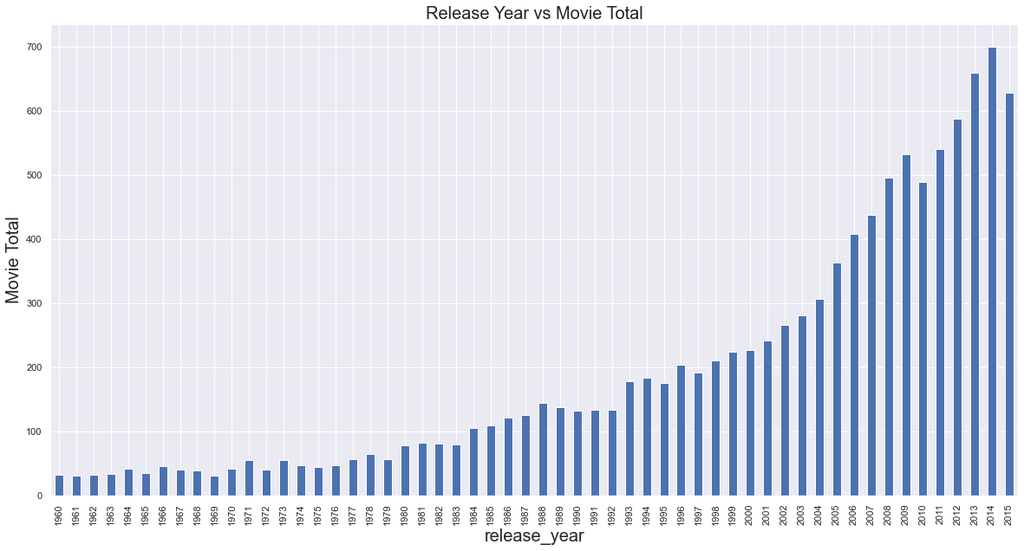

```python
# # Because I might want to draw a bar graph again later, I will create a function that will allow me to do that
# so that I can use that function everytime I want to draw a graph
def bargraph_plot(x, xlabel, ylabel, title):
    """
    This function will plot a bargraph based on the parameters passed on:
    x (string): the series you want to plot
    xlabel (string): the label on the x-axis
    ylabel (string): the label on the y-axis
    title(string): the title of the graph
    """
    mplt.xlabel(xlabel, fontsize=20)
    mplt.ylabel(ylabel, fontsize=20)
    mplt.title(title, fontsize=20)
    plot = x.plot(kind='bar', figsize=(20,10))
    sns.set_style("darkgrid")
    return plot

# Now we can get a visualization of the number of movies released in the year
bargraph_plot(release_count, 'Release Year', 'Movie Total', 'Release Year vs Movie Total')
```

From the graph above we can see that the year with the highest movie release was 2014, with a total of 700 movies released in that year.

### Research Question 2 (Which genre is the most released?)

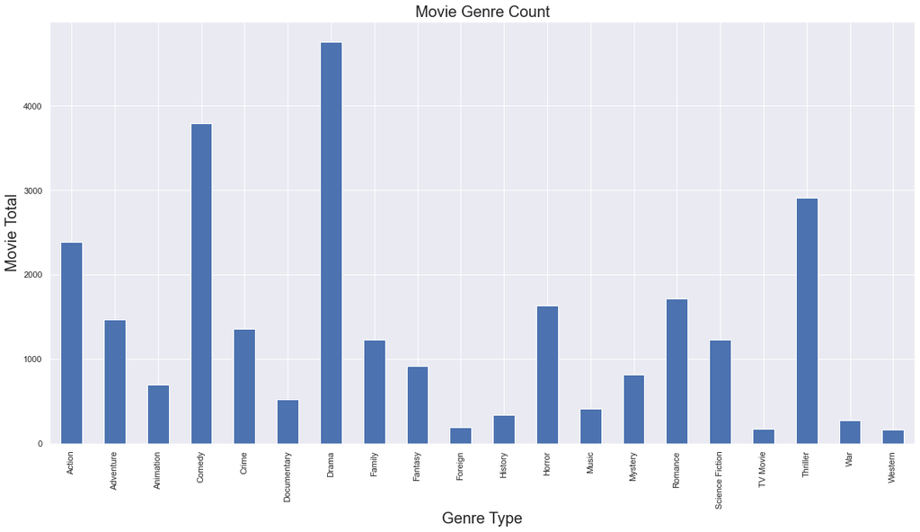

```python
# We first split the genre in the dataframe so we can look at them individually
genres_group = tmdb_movies.genres.str.split('|', expand = True)

# We want to get the count of each genre before printing it out
genres_count = genres_group[0].value_counts()
for a in range(1,5):
    b = genres_group[a].value_counts()
    genres_count = genres_count.add(b, fill_value=0)

# This will give you a visualization of what was coded above
bargraph_plot(genres_count, 'Genre Type', 'Movie Total', 'Movie Genre Count')
```

From the graph above we can see that the genre that was the most released was Drama. This could mean that people love to watch more dramas than the other genres thats why its the one producers and directors prefer to create mor than the rest.

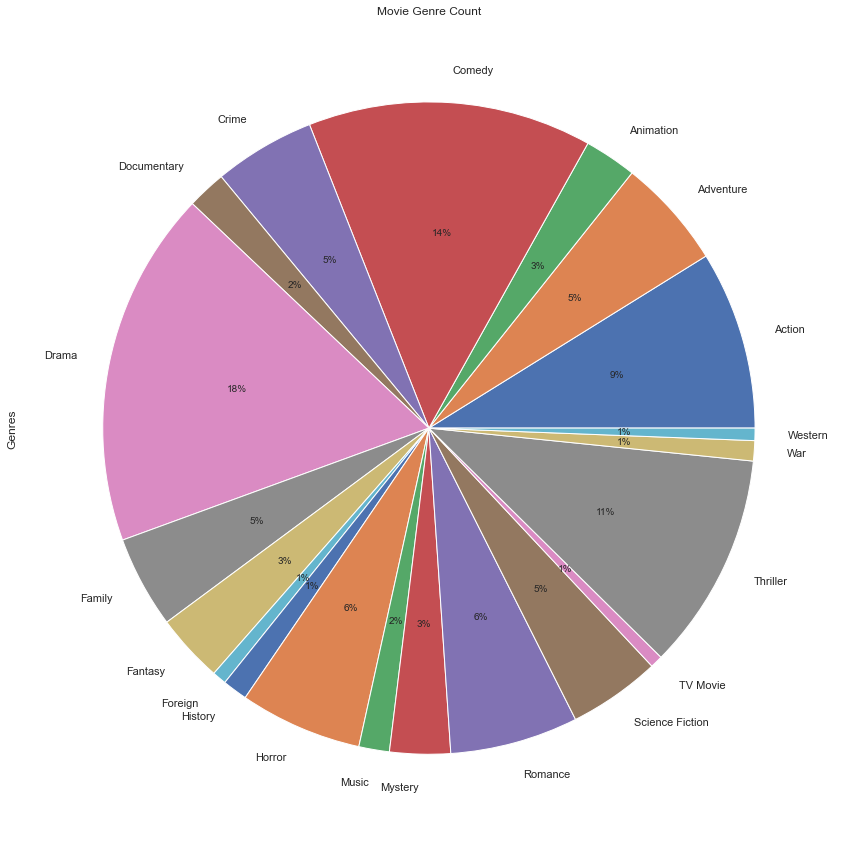

```python
# Another way to visualize this question would be with a pie chart as this would make the visuals more nicer and clearer to view.
genres_count.plot(kind='pie', title='Movie Genre Count', ylabel='Genres', autopct='%1.0f%%', figsize=(15,15))
```

With a pie chart the visuals becomes more clear, we can even go on further to say that the top 3 movie genres are Drama(18%), Comedy(14%) and Thriller(11%).

### Research Question 3 (Which movie gained the highest vote?)

```python
# We just want to sort the data by highest to smallest just to get the movie with the highest vote on top and the lowest at the bottom
highrate_movies=tmdb_movies.sort_values(by='vote_average', ascending = False)
highrate_movies[['original_title','release_year', 'vote_average']].head()
```

|  | original_title | release_year | vote_average |
| --- | --- | --- | --- |
| 3894 | The Story of Film: An Odyssey | 2011 | 9.2 |
| 538 | The Mask You Live In | 2015 | 8.9 |
| 1200 | Black Mirror: White Christmas | 2014 | 8.8 |
| 2269 | Life Cycles | 2010 | 8.8 |
| 6911 | Pink Floyd: Pulse | 2006 | 8.7 |

From this we can see that the most popular with the highest vote was "The Story of Film: An Odyssey" released in 2011 and it got an average vote of 9.2